# Introductory Data Science for Innovation. W1 - Exercises

David Eggleton

2023-09-12

# 1. Do simple computations

Simple computation (Use any number. Try it in the Console too. Remember it’s Ctrl + Enter to run a single line in a .R file but in a .Rmd file you can also click ‘play’). Try out:

- addition
- subtraction
- multiplication
- division

# 2. Use variable ‘a’ in cumulative steps

- Assign the value 1 to a variable called a. Key command for <- is ‘Alt’/‘Option’ + ‘-’
- Add 1 to a and assign it back to a
- Subtract a from 10 and assign it back to a
- Multiply a by 4 and assign it back to a
- Divide a by 2 and reassign it back to a
- Create a new variable for the ‘expected value of a’ and set it equal to 16
- Check if value of a is right (if it returns true you are right, if false you are wrong).

Go back in code and assign a different value to a (such as 10 or 5) and rerun the code above. Just play around - you can’t break it and even if you do just revert to the git.

# 3. Including Plots

You can also embed plots so it’s a bit easier to see, for example:

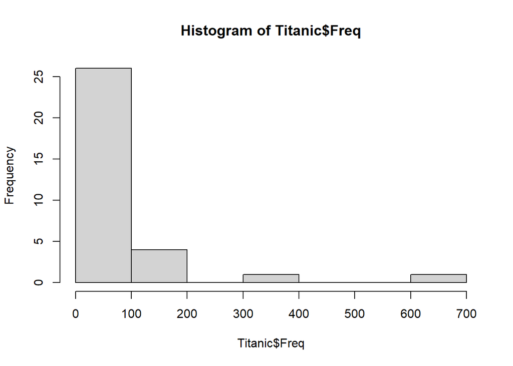

# 4. Work with packages

Try to install a library whether in the console or here. Tidyverse is a good idea because you’re going to be using it a lot. Syntax is a bit weird but you’ll get used to it. Installation requires quotes, loading the library doesn’t